# Assignment 3

[output not shown]

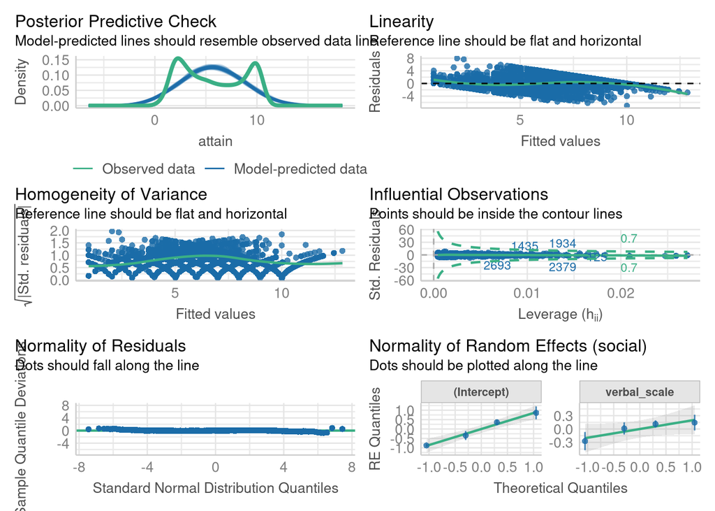

```r
M_j3<-lmerTest::lmer(attain~ verbal_scale+(verbal_scale|social),data,REML = TRUE)
performance::check_model(M_j3)
```

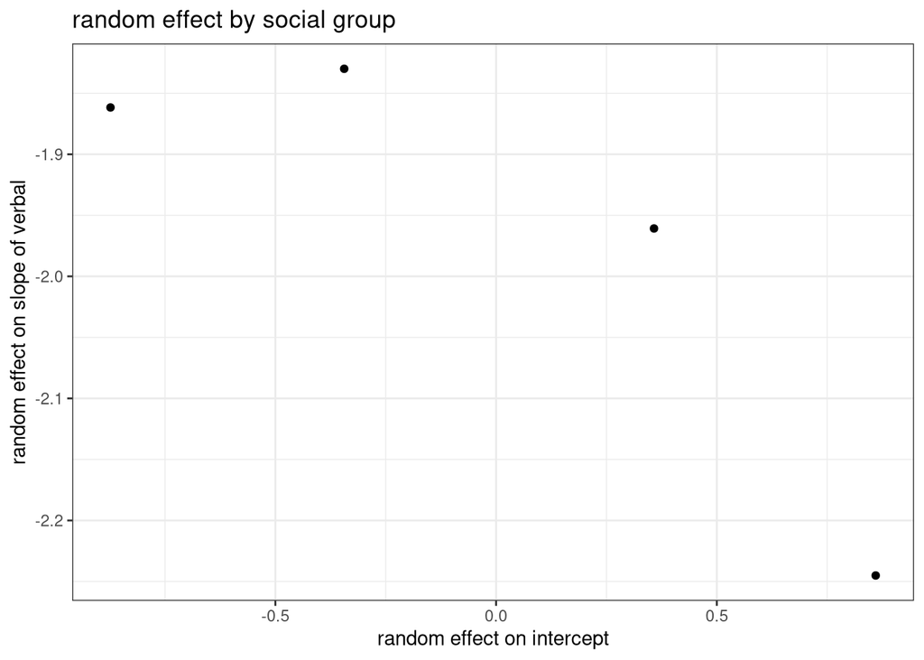

```r
ransom<-lme4::ranef(M_j3)$social
fixed<-glmmTMB::fixef(M_j3)["verbal_scale"]
ransom$deviation<-ransom$verbal_scale-fixed
colnames(ransom)[1]="Intercept"
ransom|> ggplot2::ggplot(aes(x=Intercept,y=deviation))+geom_point()+labs(x="random effect on intercept",y="random effect on slope of verbal",title = "random effect by social group")+theme_bw()
```

By combining the results from methods 1 and 2, we can see that the “social” factor is not clearly significant in identifying the model’s influence on the intercept and/or slope at different levels of “social.”

**BMB**: don’t combine ‘clearly’ with ‘significant’

## k.

```r
train_id<-sample(1:nrow(data),nrow(data)*0.7)
Train_data<-data[train_id,]
Test_data<-data[-train_id,]
M_knew<-lmerTest::lmer(attain~verbal_scale+sex+(sex|primary),Train_data,REML = TRUE)
```

```
boundary (singular) fit: see help('isSingular')
```

```r
M_k<-lmerTest::lmer(attain~verbal_scale+sex+social+(sex|primary),Train_data,REML=TRUE)
predictnew<-predict(M_knew,Test_data,allow.new.levels=TRUE)
predict<-predict(M_k,Test_data,allow.new.levels=TRUE)
Test_errornew<-sqrt(sum((Test_data$attain-predictnew)^2))
Test_error<-sqrt(sum((Test_data$attain-predict)^2))
Test_errornew>Test_error
```

```
[1] TRUE
```

```r
all.equal(Test_errornew,Test_error,tolerance = 0.1)
```

```
[1] TRUE
```

We split the data into two parts, using a 70/30 ratio, and then tested the error rates of two models. One model retains the fixed effect of social factors, while the other discards it. Upon comparing the test errors of the two models, we found that the model which keeps the social fixed effect has a smaller error compared to the other model.

**BMB**: splitting data in this way doesn’t work right when the data are grouped so that values are not all conditionally iid. If you want to do this, you need to split in a way that is stratified by clusters.

## l.

```r
M_l<-lmerTest::lmer(attain~verbal_scale+sex+social+(1|primary),data,REML = TRUE)
Aic_new<-AIC(M_l)
Aic_ori<-AIC(model_3)
Aic_new>Aic_ori
```

```
[1] TRUE
```

```r
#Hypothesis test one-LRT
Test1<-anova(M_l,model_3)
```

```
refitting model(s) with ML (instead of REML)
```

```r
Test1$`Pr(>Chisq)`
```

```
[1]         NA 0.00442487
```

```r
#Hypothesis test two-test statistics
pbkrtest::PBmodcomp(M_l,model_3)
```

```
boundary (singular) fit: see help('isSingular')
```

[output not shown]

```
Bootstrap test; time: 129.46 sec;samples: 1000; extremes: 0;
Requested samples: 1000 Used samples: 0 Extremes: 0
large : attain ~ verbal_scale + sex + social + (1 | primary)
small : attain ~ verbal_scale + sex + social + (sex | primary)
          stat df p.value
LRT    -10.836 -2     NaN
PBtest -10.836          1
```

The random effect of sex by the primary group variable is significantly different from 0, as indicated by the likelihood ratio test. Additionally, the AIC suggests that the original model, which includes the random effect of sex on the slope, is better than the reduced model.